# Statistical Testing

Statistical inference lets us infer the properties of the population when only a subset of the population is given. This is useful because in reality we don't typically have all the data concerning one population but we are still interested in finding out the characteristics of the whole population. Hypothesis testing is one way we use to learning about the population's characteristics.

## Hypothesis Testing

We can use hypothesis testing to measure the probability of a null hypothesis is true. In such a testing, we denote the null hypothesis as *H*<sub>0</sub> and the alternative hypothesis as *H*<sub>*a*</sub>. Let's go through how to set up the hypothesis testing again before diving into the details.

1. Establish a null hypothesis *H*<sub>0</sub> and an alternative hypothesis *H*<sub>*a*</sub>.
2. Find an appropriate statistical test to assess the null hypothesis.
3. Derive the distribution under the null hypothesis such as a normal distribution.
4. Select a significant level as the threshold below which the null hypothesis will be rejected.
5. Computer the p value.
6. Decide if we reject the null hypothesis or we fail to reject. We never accept a null hypothesis in a testing.

## Chi-square Test for Independence

We use Chi-square test for independence to demonstrate how we do hypothesis testing.

```r
tutorialsOb <- matrix(c(30, 20, 20, 30), ncol = 2, byrow = TRUE)
colnames(tutorialsOb) <- c("Get good grades","Get bad grades")
rownames(tutorialsOb) <- c("Attend tutorials", "Don't attend tutorials")
tutorialsOb <- as.table(tutorialsOb)
addmargins(tutorialsOb)
```

```r
##                        Get good grades Get bad grades Sum
## Attend tutorials                    30             20  50
## Don't attend tutorials              20             30  50
## Sum                                 50             50 100
```

Since Chi-square test is used for testing if one variable is independent from another. We use a two way table that entails two variables `attending tutorials or not` and `grades` of the stats class. We follow the steps from last section.

### Step 1 and Step 2

We first formulate the null hypothesis which is attending tutorials is independent from getting good grades. So our expected observations should be like

```r
##                        Get good grades Get bad grades Sum
## Attend tutorials                    25             25  50
## Don't attend tutorials              25             25  50
## Sum                                 50             50 100
```

We already know we should be using chi-square test. So we can skip the second step.

### Step 3 Chisquare distribution

The degree of freedom is calculated by *d**f* = (*r**o**w**N**u**m**b**e**r* − 1) * (*c**o**l**u**m**n**N**u**m**b**e**r* − 1) Just to see a few distributions of different degrees of freedom to get an idea

```r
library(visualize)
old.par <- par(mfrow=c(2, 2))
visualize.chisq(stat = 0, df = 1, section = "lower")
visualize.chisq(stat = 0, df = 2, section = "lower")
visualize.chisq(stat = 0, df = 3, section = "lower")
visualize.chisq(stat = 0, df = 4, section = "lower")
```

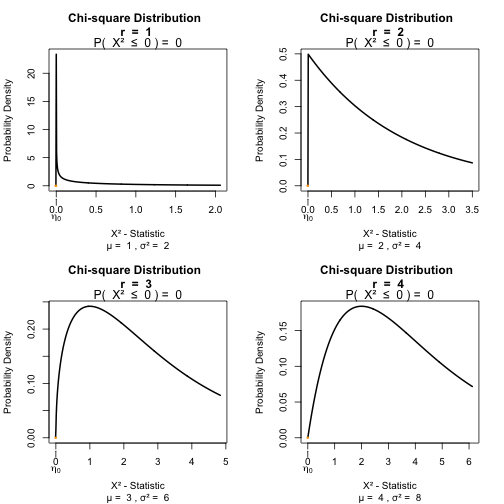

```r
par(old.par)
```

### Step 5 calculate the probability based on the distribution

We can calculate the chi-square value using  
${\chi}^2=\sum_{k=1}^{n} \frac{(O_k - E_k)^2}{E_k}$  
we plug our data into the formula such that we get  
$\frac{(30-25)^2}{25} + \frac{(20-25)^2}{25} + \frac{(20-25)^2}{25} + \frac{(30-25)^2}{25} = 1 + 1 + 1 + 1 = 4$  
*χ*<sup>2</sup> = 4  
Our degree of freedom is 1 so that we can get the probability from the distribution we get a p of 0.0455. Now we visulize what is happening and verify our computation:

```r
visualize.chisq(stat = 4, df = 1, section = "lower")
```

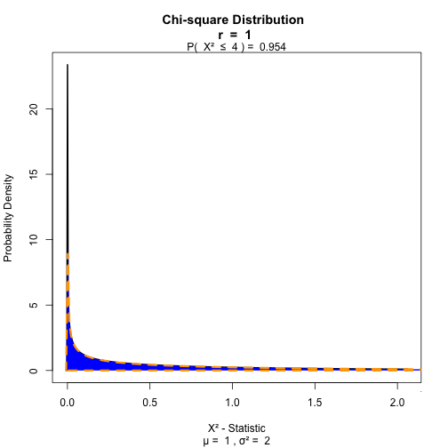

```r
test_result <- chisq.test(tutorialsOb, correct = FALSE)
test_result$observed
```

```r
##                        Get good grades Get bad grades
## Attend tutorials                    30             20
## Don't attend tutorials              20             30
```

```r
test_result$expected
```

```r
##                        Get good grades Get bad grades
## Attend tutorials                    25             25
## Don't attend tutorials              25             25
```

```r
test_result
```

```r
##
##  Pearson's Chi-squared test
##
## data:  tutorialsOb
## X-squared = 4, df = 1, p-value = 0.0455
```

### Step 6 conclusion

Since we p value is smaller than our significance level, we can reject the null hypothesis can conclude that attending the tutorials has an influence on the grades that people get.

Styled with knitrBootstrap